# Discussion 8

Ozan Sonmez

February 27, 2017

# Frequency Domain:

Note: The J&J data set, and the SOI and recruitment data set are available in the R package `astsa`.

In order to define the rate at which a series oscillates, we first define a cycle as one complete period of a sine or cosine function defined over a unit time interval. We consider the periodic process
$$x_t = A\cos(2\pi wt+\phi)$$
for $t=0,\pm 1, \pm 2, \dots$, where $w$ is a frequency index, defined in cycles per unit time with $A$ determining the height or amplitude of the function and $\phi$, called the phase, determining the start point of the cosine function. We can introduce random variation in this time series by allowing the amplitude and phase to vary randomly.

$$\begin{align*}
x_t &= A\cos(2\pi wt+\phi) \\
& = A[\cos(2\pi wt)\cos(\phi)-\sin(2\pi wt)sin(\phi)]\\
& = \underbrace{A\cos(\phi)}_{U_1}\cos(2\pi wt) \underbrace{- A\sin(\phi)}_{U_2}\sin(2\pi wt)\\
& = U_1\cos(2\pi wt) + U_2\sin(2\pi wt)
\end{align*}$$

$U_1$ and $U_2$ are often taken to be normally distributed random variables. In this case, the amplitude is $A=\sqrt{U_1^2+U_2^2}$ and the phase is $\phi=\tan^{-1}(-U_2/U_1)$. Or one can consier the generalization, i.e.,
$$x_t = \sum_{k=1}^q[U_{k1}\cos(2\pi w_kt) + U_{k2}2\sin(2\pi w_kt)]$$
with an autocovariance function:
$$\gamma_x(h)=\sum_{k=1}^q\cos(2\pi w_kh)\sigma_k^2$$
with variance
$$\gamma_x(0)=\sum_{k=1}^q\sigma_k^2$$

## Periodic Series:

Consider an example of the mixture (given above) with $q = 3$ constructed in the following way. First, for $t = 1, . . . , 100$, we generate three series
$$x_{t1} = 2\cos(2\pi t (6/100))+3\sin(2\pi t (6/100))$$
$$x_{t2} = 4\cos(2\pi t (10/100))+5\sin(2\pi t (10/100))$$
$$x_{t3} = 6\cos(2\pi t (40/100))+7\sin(2\pi t (40/100))$$

These three series are displayed below along with the corresponding frequencies and squared amplitudes. For example, the squared amplitude of $x_{t1}$ is $A^2 = 2^2 + 3^2 = 13$. Hence, the maximum and minimum values that $x_{t1}$ will attain are $\pm\sqrt{13} = \pm 3.61$. Finally, we constructed
$$xt = x_{t1}+x_{t2}+x_{t3}$$
and this series is also displayed below. We note that $x_t$ appears to behave as some of the periodic series we have already seen.

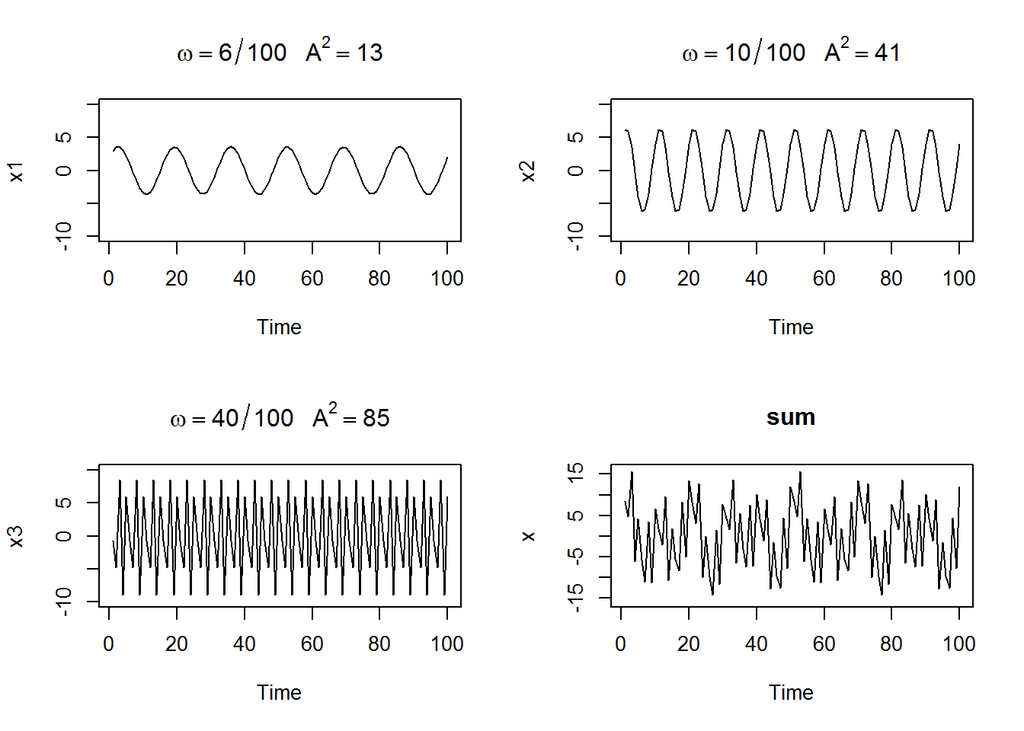

```r
t = 1:100
x1 = 2*cos(2*pi*t*6/100) + 3*sin(2*pi*t*6/100)
x2 = 4*cos(2*pi*t*10/100) + 5*sin(2*pi*t*10/100)
x3 = 6*cos(2*pi*t*40/100) + 7*sin(2*pi*t*40/100)
x =x1+x2+x3

par(mfrow=c(2,2))
plot.ts(x1, ylim=c(-10,10), main=expression(omega==6/100~~~A^2==13))
plot.ts(x2, ylim=c(-10,10), main=expression(omega==10/100~~~A^2==41))
plot.ts(x3, ylim=c(-10,10), main=expression(omega==40/100~~~A^2==85))
plot.ts(x,  ylim=c(-16,16), main="sum")
```

## Periodogram

A basic idea in mathematics and statistics is to take a complicated object (such as a time series) and break it up into the sum of simple objects that can be studied separately, see which ones can be thrown away as being unimportant, and then adding what’s left back together again to obtain an approximation to the original object. The periodogram of a time series is the result of such a procedure.

We will use the terms low frequency and high frequency extensively. The basic idea is that sinusoids of low frequency (or equivalently long period) are smooth in appearance whereas those of high frequency (or short period) are very wiggly. Thus if a time series appears to be very smooth (wiggly), then the values of the periodogram for low (high) frequencies will be large relative to its other values and we will say that the data set has an excess of low (high) frequency. For a purely random series, all of the sinusoids should be of equal importance and thus the periodogram will vary randomly around a constant.

If a time series has a strong sinusoidal signal for some frequency, then there will be a peak in the periodogram at that frequency.

If a time series has a strong nonsinusoidal signal for some frequency, then there will be a peak in the periodogram at that frequency but also peaks at some multiples of that frequency. The first frequency is called the fundamental frequency and the others called harmonics.

Fo any time series sample $x_1, x_2, \dots, x_n$, it can be written as (for $n$ is odd)

$$x_t = a_0 +\sum_{j=1}^{(n-1)/2}[a_j\cos(2\pi t j/n)+b_j\sin(2\pi t j/n)]$$

We then define the scaled periodogram to be
$$P(j/n) = a_j^2+b_j^2$$

because it indicates which frequency components are large in magnitude and which components are small. The scaled periodogram is the estimate of $\sigma_j^2$ corresponding to the sinusoid oscillating at a frequency of $w_j = j/n$, or $j$ cycles in $n$ time points. These particular frequencies are called the Fourier or fundamental frequencies. Large values of $P(j/n)$ indicate which frequencies $w_j = j/n$ are predominant in the series, whereas small values of $P(j/n)$ may be associated with noise.

Noe that
$$P(j/n) = P(1-j/n)$$
We can also calculate the scaled periodogram using the discrete Fourier transform:
$$P(j/n) = \frac{4}{n}|d(j/n)|^2$$

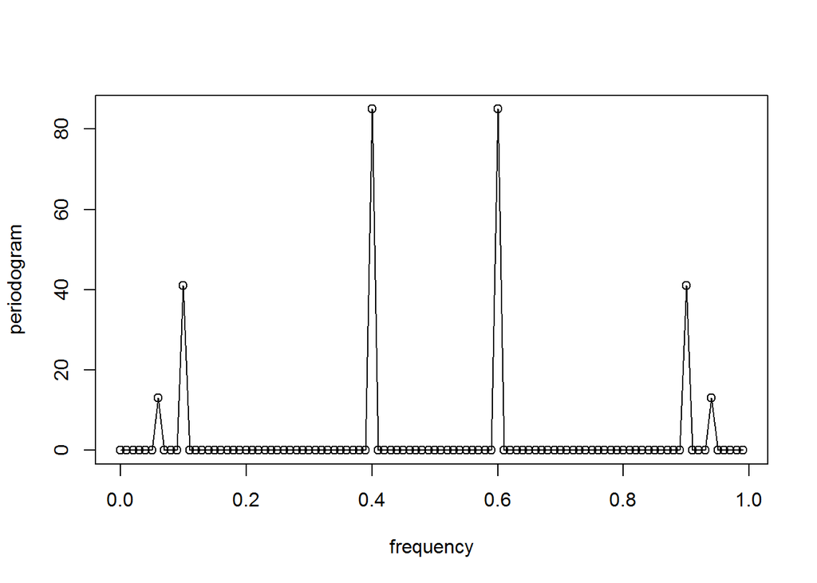

```r
P = 4*abs(fft(x)/100)^2
Fr = 0:99/100
plot(Fr, P, type="o", xlab="frequency", ylab="periodogram")
```

as expected, the dominant frquencies are $0.06, 0.10, 0.40$ and their complements. One can also use the R function $spec.pgram()$, and the peaks will give the dominent frequencies, i.e.:

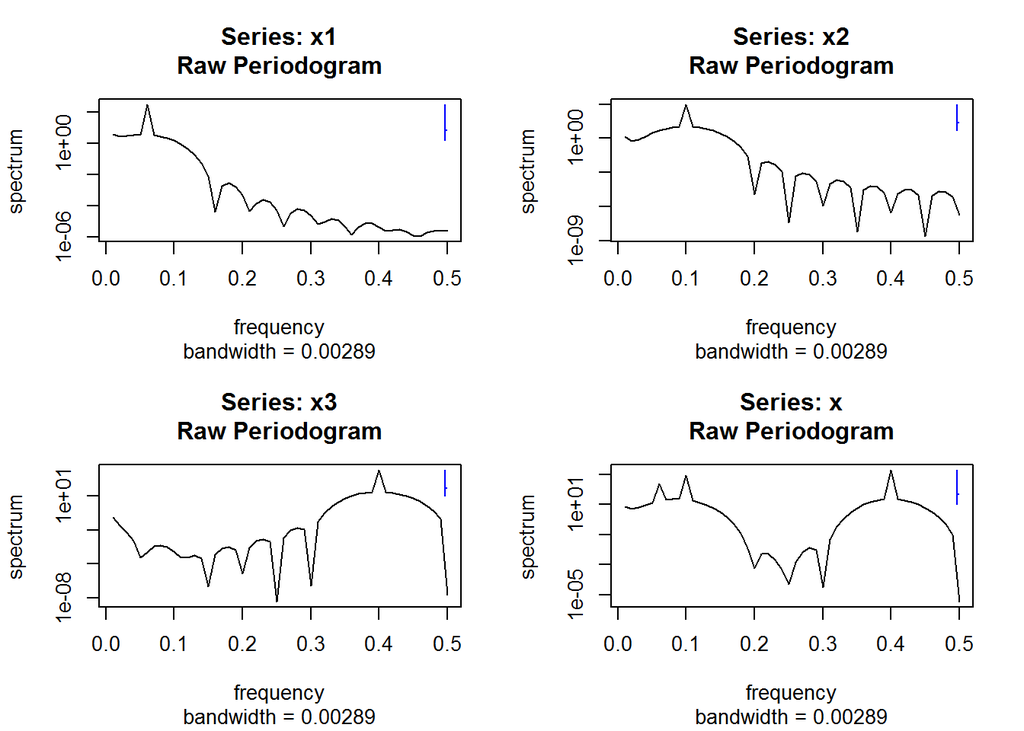

```r
par(mfrow=c(2,2))
spec.pgram(x1)
spec.pgram(x2)
spec.pgram(x3)
spec.pgram(x)
```

# Problem 4.1

## Part a

Generate and plot the same four series described above ($x_{t1},x_{t2},x_{t3},x_{t}$), but change the sample size to $n=128$. What changes about the way the plots look?

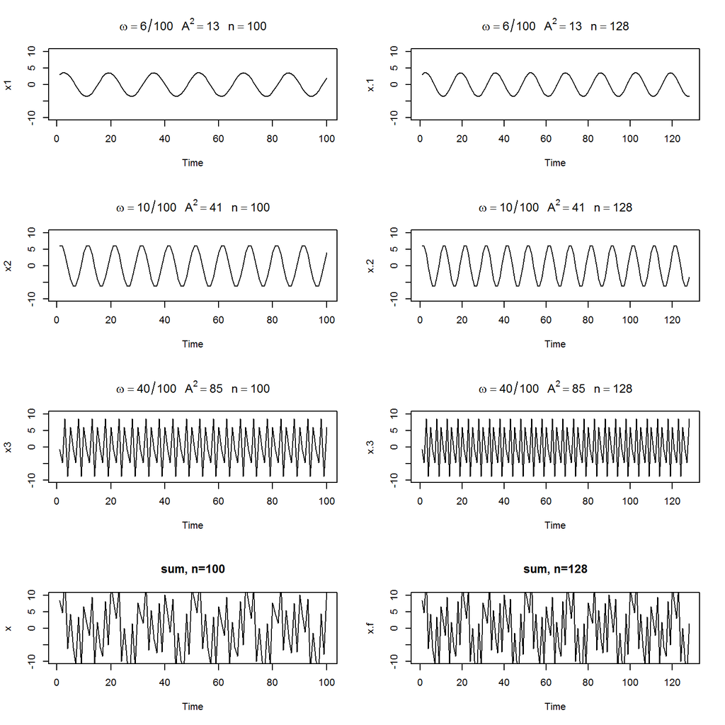

```r
t = 1:128
x.1 = 2*cos(2*pi*t*6/100) + 3*sin(2*pi*t*6/100)
x.2 = 4*cos(2*pi*t*10/100) + 5*sin(2*pi*t*10/100)
x.3 = 6*cos(2*pi*t*40/100) + 7*sin(2*pi*t*40/100)
x.f =x.1+x.2+x.3

par(mfrow=c(4,2))
plot.ts(x1, ylim=c(-10,10), main=expression(omega==6/100~~~A^2==13~~~n==100))
plot.ts(x.1, ylim=c(-10,10), main=expression(omega==6/100~~~A^2==13~~~n==128))
plot.ts(x2, ylim=c(-10,10), main=expression(omega==10/100~~~A^2==41~~~n==100))
plot.ts(x.2, ylim=c(-10,10), main=expression(omega==10/100~~~A^2==41~~~n==128))
plot.ts(x3, ylim=c(-10,10), main=expression(omega==40/100~~~A^2==85~~~n==100))
plot.ts(x.3, ylim=c(-10,10), main=expression(omega==40/100~~~A^2==85~~~n==128))
plot.ts(x, ylim=c(-10,10), main="sum, n=100")
plot.ts(x.f, ylim=c(-10,10), main="sum, n=128")
```

## Part b

Compute and plot the periodogram of the newly generated series. You may use the R function $spec.pgram()$. Comment on the changes. It may help to plot the original periodograms and the new ones side-by-side.

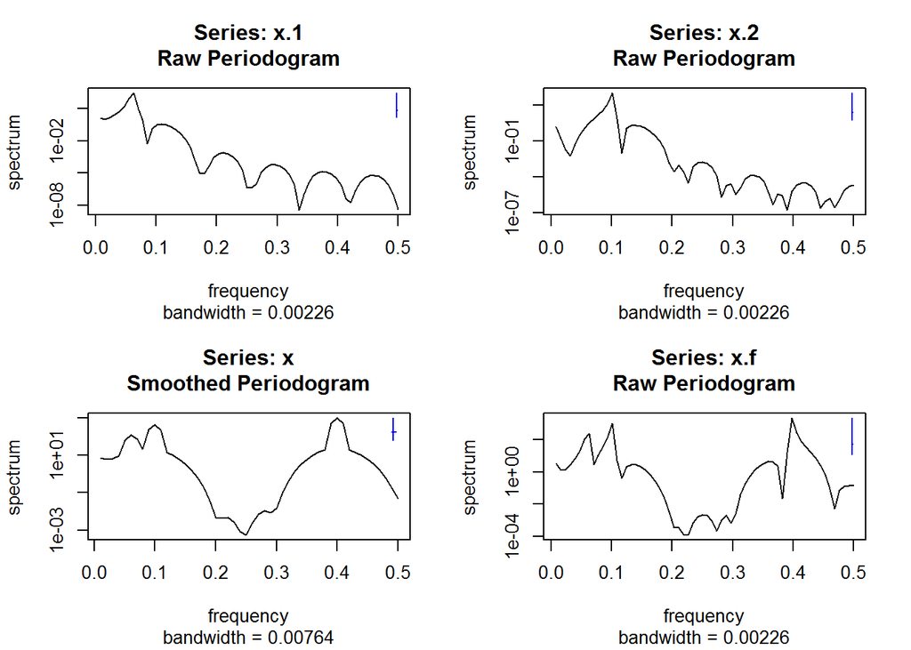

```r
par(mfrow=c(2,2))
spec.pgram(x.1)
spec.pgram(x.2)
spec.pgram(x,3)
spec.pgram(x.f)
```

### Part c

Add a noise term to the mixture series with $n=100$. That is, use $x_t = x_{t1} + x_{t2} + x_{t3} + w_t$, where $\{w_t\}$ is WN($0,5$). Plot the series and the periodogram. How does the periodogram compare to the one from before the noise was added in?

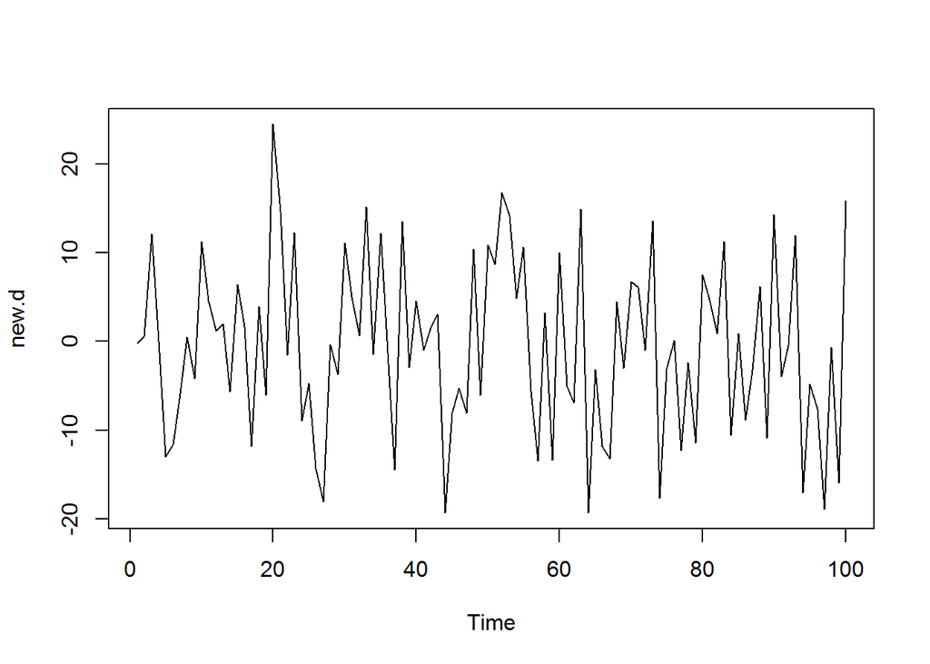

```r
new.d = x + rnorm(100,0,5)
plot.ts(new.d)
```

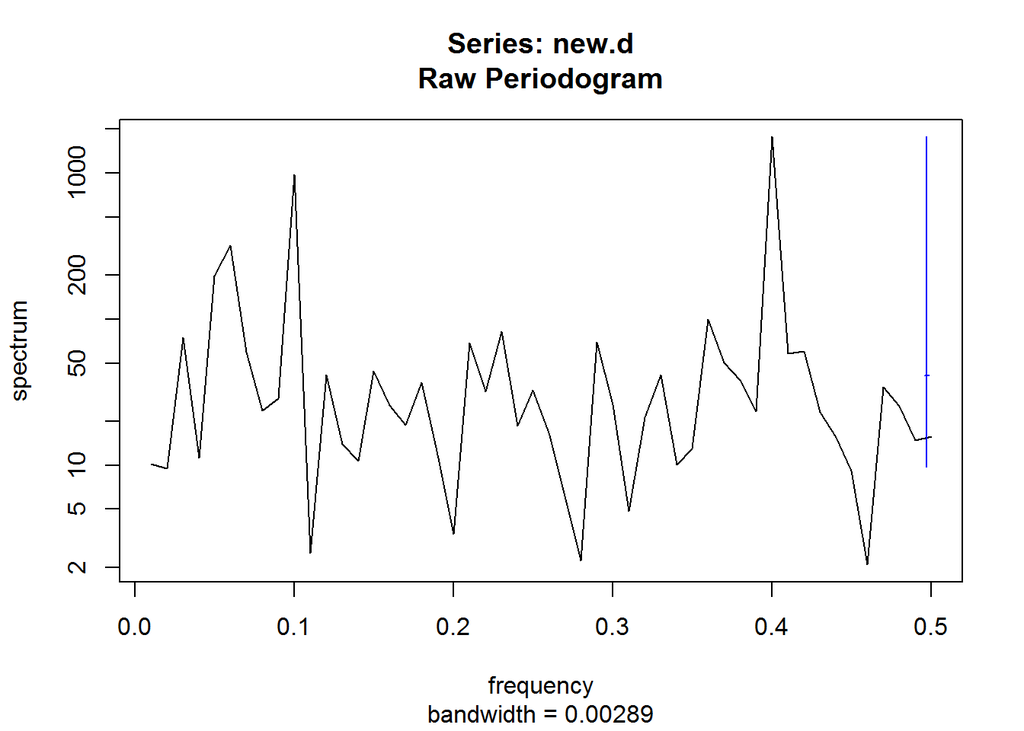

```r
spec.pgram(new.d)
```

The pediogram of the new data has the similar dominant frequencies as the the non-noisy data, and adding the white noise seems not to affect the dominant frequency.